# Applied_Statistics_Project_Submission1_Rakesh

Submission By Rakesh Kumar

Submission Date: 21st Nov 2021

Group 9 AIML Sep 21

Applied Statistics Project - 60 Marks

General Instructions:

1. Submission of all the parts is expected in 1 notebook only
2. Expected submission format: 1 ‘.ipynb’ notebook and 1 ‘.html’ notebook only
3. 50% marks will be deducted if insights/steps are missing in the corresponding questions.
4. If output for any code cell is missing, 50% marks will be deducted.
5. If any kind of plagiarism from any source is found, it will not be evaluated and zero (0) Marks will be given.

--------------------------------------------------- Part 1 -----------------------------------------15 Marks

Please answer the following questions with all relevant assumptions, explanations and details.

Q1. Please refer the table below to answer below questions:

# | Planned to Purchase | Actually placed order | Actually placed order | Total |

| Product A | For Product A - Yes | For Product B - No | |

| ------------------- | -------------------- | -------------------- | ----- |

| Yes | 400 | 100 | 500 |

| No | 200 | 1300 | 1500 |

| Total | 600 | 1400 | 2000 |

Q1.A Refer above table and find the joint probability of the people who planned to purchase and actually placed an order. [1 Mark]

```python
print
("The Joint Probability of the people who planned to purchase and actually placed an order is %1.2f" %(400/500))
```

[output not shown]

Q1.B Refer to the above table and find the joint probability of the people who planned to purchase and actually placed an order, given that people planned to purchase. [1 Mark]

```python
print
("The joint probability of the people who planned to purchase and actually placed an order, given that people planned to purchase is %1.2f" %(400/2000))
```

[output not shown]

Q2. An electrical manufacturing company conducts quality checks at specified periods on the products it manufactures. Historically, the failure rate for the manufactured item is 5%. Suppose a random sample of 10 manufactured items is selected. Answer the following questions.

A. Probability that none of the items are defective? [1 Mark]

B. Probability that exactly one of the items is defective? [1 Mark]

C. Probability that two or fewer of the items are defective? [1 Mark]

D. Probability that three or more of the items are defective ? [1 Mark]

```python
import numpy             as np
import pandas            as pd
import scipy.stats       as stats
import matplotlib.pyplot as plt
```

```python
p   =  0.05 # failure rate for manufactured item
n   =  10 # sample size
k   =  np.arange(0,n+1) # Array
```

```python
binomial = stats.binom.pmf(k,n,p)
binomial
```

```
array([5.98736939e-01, 3.15124705e-01, 7.46347985e-02, 1.04750594e-02,
       9.64808106e-04, 6.09352488e-05, 2.67259863e-06, 8.03789063e-08,
       1.58642578e-09, 1.85546875e-11, 9.76562500e-14])
```

```python
# A. Probability that none of the items are defective?
print('Probability of None of the LED bulbs are defective is %1.2f' %binomial[0])
```

```
Probability of None of the LED bulbs are defective is 0.60
```

```python
# B. Probability that exactly one of the items is defective?
print('Probability of None of the LED bulbs are defective is %1.2f' %binomial[1])
```

[output not shown]

```python
Cum_Prob = stats.binom.cdf(k,n,p)
Cum_Prob
```

```
array([0.59873694, 0.91386164, 0.98849644, 0.9989715 , 0.99993631,
       0.99999725, 0.99999992, 1.        , 1.        , 1.        ,
       1.        ])
```

```python
# C. Probability that two or fewer of the items are defective?
print('Probability that two or fewer of the items are defective is %1.2f' %Cum_Prob[2])
```

```
Probability that two or fewer of the items are defective is 0.99
```

```python
#D. Probability that three or more of the items are defective ?
print('Probability that three or more of the items are defective is %1.2f' %(1-Cum_Prob[2]))
```

```
Probability that three or more of the items are defective is 0.01
```

Q3. A car salesman sells on an average 3 cars per week.

A. What is Probability that in a given week he will sell some cars. [1 Mark]

B. What is Probability that in a given week he will sell 2 or more but less than 5 cars.[1Mark]

C. Plot the poisson distribution function for cumulative probability of cars sold per-week vs number of cars sold per week. [1 Mark]

```python
rate =  3 #Mean value
n    =  np.arange(0,20)
poisson = stats.poisson.pmf(n,rate)
Cum_poisson = stats.poisson.cdf(n,rate)
print(poisson)
print(Cum_poisson)
```

```
[4.97870684e-02 1.49361205e-01 2.24041808e-01 2.24041808e-01
 1.68031356e-01 1.00818813e-01 5.04094067e-02 2.16040315e-02
 8.10151179e-03 2.70050393e-03 8.10151179e-04 2.20950322e-04
 5.52375804e-05 1.27471339e-05 2.73152870e-06 5.46305740e-07
 1.02432326e-07 1.80762929e-08 3.01271548e-09 4.75691918e-10]
[0.04978707 0.19914827 0.42319008 0.64723189 0.81526324 0.91608206
 0.96649146 0.9880955  0.99619701 0.99889751 0.99970766 0.99992861
 0.99998385 0.9999966  0.99999933 0.99999988 0.99999998 1.
 1.         1.        ]
```

```python
print('Probability that in a given week he will sell some cars is %1.2f' %(1-poisson[0]))
```

```
Probability that in a given week he will sell some cars is 0.95
```

```python
print('Probability that in a given week he will sell 2 or more but less than 5 cars is %1.2f' %(poisson[2]+poisson[3]+poisson[4]))
```

```
Probability that in a given week he will sell 2 or more but less than 5 cars is 0.62
```

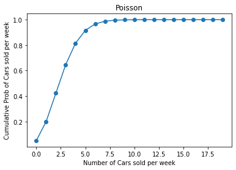

```python
#poisson distribution function for cumulative probability of cars sold per-week vs number of cars sold per week.
plt.plot(n,Cum_poisson, 'o-')
plt.title('Poisson')
plt.xlabel('Number of Cars sold per week')
plt.ylabel('Cumulative Prob of Cars sold per week')
plt.show()
```

Q4. Accuracy in understanding orders for a speech based bot at a restaurant is important for the Company X which has designed, marketed and launched the product for a contactless delivery due to the COVID-19 pandemic. Recognition accuracy that measures the percentage of orders that are taken correctly is 86.8%. Suppose that you place an order with the bot and two friends of yours independently place orders with the same bot.

Answer the following questions.

A. What is the probability that all three orders will be recognised correctly? [1 Mark]

B. What is the probability that none of the three orders will be recognised correctly? [1Mark]

C. What is the probability that at least two of the three orders will be recognised correctly?[1Mark]

```python
k   =  np.arange(0,4)
p=0.868
n=3
binomial = stats.binom.pmf(k,n,p)
binomial
```

```
array([0.00229997, 0.0453721 , 0.2983559 , 0.65397203])
```

```python
#What is the probability that all three orders will be recognised correctly?

print('Probability that all three orders will be recognised correctly is %1.2f' %binomial[3])
```

```
Probability that all three orders will be recognised correctly is 0.65
```

```python
#What is the probability that none of the three orders will be recognised correctly?

print('Probability that none of the three orders will be recognised correctly is %1.4f' %binomial[0])
```

```
Probability that none of the three orders will be recognised correctly is 0.0023
```

```python
#What is the probability that none of the three orders will be recognised correctly?

print('Probability that at least two of the three orders will be recognised correctly is %1.4f' %(binomial[2]+binomial[3]))
```

```
Probability that at least two of the three orders will be recognised correctly is 0.9523
```

Q5. Explain 1 real life industry scenario (other than the ones mentioned above) where you can use the concepts learnt in this module of Applied statistics to get a data driven business solution. [3 Marks]

Real life scenario: Let us assume Myntra introduces a ChatBot functionality to its customers to assist them in the Buying process. They want to check if using chat bot increases the average sale conversion rate. Let us assume average conversion rate is 20%.

Null Hypothesis Ho: Enabling Chatbot has no effect on Sale conversion rate (µ=20%) Alternate Hypothesis: Enabling Chatbot increases the Sale conversion rate.(µ>20%)

We can use a large enough sample and test the hypothesis using Z test. We can either accept or reject the Hypothesis using the p value. (Confidance interval of 95%)

--------------------------------------------------- Part 2 -----------------------------------------30 Marks

Context: Company X manages the men's top professional basketball division of the American league system. The dataset contains information on all the teams that have participated in all the past tournaments. It has data about how many baskets each team scored, conceded, how many times they came within the first 2 positions, how many tournaments they have qualified, their best position in the past, etc.

1. Read the data set, clean the data and prepare final dataset to be used for analysis. [10 Marks]

```python
import pandas as pd
import numpy as np
import matplotlib.pyplot as plt
import seaborn as sns
```

```python
df=pd.read_csv('DS+-+Part2+-+Basketball.csv',header=0)
df.info()
```

```
<class 'pandas.core.frame.DataFrame'>
RangeIndex: 61 entries, 0 to 60
Data columns (total 13 columns):
 #   Column               Non-Null Count  Dtype
---  ------               --------------  -----
 0   Team                 61 non-null     object
 1   Tournament           61 non-null     int64
 2   Score                61 non-null     object
 3   PlayedGames          61 non-null     object
 4   WonGames             61 non-null     object
 5   DrawnGames           61 non-null     object
 6   LostGames            61 non-null     object
 7   BasketScored         61 non-null     object
 8   BasketGiven          61 non-null     object
 9   TournamentChampion   61 non-null     object
 10  Runner-up            61 non-null     object
 11  TeamLaunch           61 non-null     object
 12  HighestPositionHeld  61 non-null     int64
dtypes: int64(2), object(11)
memory usage: 6.3+ KB
```

```python
df.head()
```

|  | Team | Tournament | Score | PlayedGames | WonGames | DrawnGames | LostGames | BasketScored | BasketGiven | TournamentChampion | Runner-up | TeamLaunch | HighestPositionHeld |
| --- | --- | --- | --- | --- | --- | --- | --- | --- | --- | --- | --- | --- | --- |
| 0 | Team 1 | 86 | 4385 | 2762 | 1647 | 552 | 563 | 5947 | 3140 | 33 | 23 | 1929 | 1 |
| 1 | Team 2 | 86 | 4262 | 2762 | 1581 | 573 | 608 | 5900 | 3114 | 25 | 25 | 1929 | 1 |
| 2 | Team 3 | 80 | 3442 | 2614 | 1241 | 598 | 775 | 4534 | 3309 | 10 | 8 | 1929 | 1 |
| 3 | Team 4 | 82 | 3386 | 2664 | 1187 | 616 | 861 | 4398 | 3469 | 6 | 6 | 1931to32 | 1 |
| 4 | Team 5 | 86 | 3368 | 2762 | 1209 | 633 | 920 | 4631 | 3700 | 8 | 7 | 1929 | 1 |

```python
df.tail()
```

|  | Team | Tournament | Score | PlayedGames | WonGames | DrawnGames | LostGames | BasketScored | BasketGiven | TournamentChampion | Runner-up | TeamLaunch | HighestPositionHeld |
| --- | --- | --- | --- | --- | --- | --- | --- | --- | --- | --- | --- | --- | --- |
| 56 | Team 57 | 1 | 34 | 38 | 8 | 10 | 20 | 38 | 66 | - | - | 2009-10 | 20 |
| 57 | Team 58 | 1 | 22 | 30 | 7 | 8 | 15 | 37 | 57 | - | - | 1956-57 | 16 |
| 58 | Team 59 | 1 | 19 | 30 | 7 | 5 | 18 | 51 | 85 | - | - | 1951~52 | 16 |
| 59 | Team 60 | 1 | 14 | 30 | 5 | 4 | 21 | 34 | 65 | - | - | 1955-56 | 15 |
| 60 | Team 61 | 1 | - | - | - | - | - | - | - | - | - | 2017~18 | 9 |

```python
df1=df
df1.replace('-',0,inplace=True)
df1['TeamLaunch']=df1['TeamLaunch'].str[:4]
df1=df1.apply(pd.to_numeric, errors='ignore')
df1.info()
```

```
<class 'pandas.core.frame.DataFrame'>
RangeIndex: 61 entries, 0 to 60
Data columns (total 13 columns):
 #   Column               Non-Null Count  Dtype
---  ------               --------------  -----
 0   Team                 61 non-null     object
 1   Tournament           61 non-null     int64
 2   Score                61 non-null     int64
 3   PlayedGames          61 non-null     int64
 4   WonGames             61 non-null     int64
 5   DrawnGames           61 non-null     int64
 6   LostGames            61 non-null     int64
 7   BasketScored         61 non-null     int64
 8   BasketGiven          61 non-null     int64
 9   TournamentChampion   61 non-null     int64
 10  Runner-up            61 non-null     int64
 11  TeamLaunch           61 non-null     int64
 12  HighestPositionHeld  61 non-null     int64
dtypes: int64(12), object(1)
memory usage: 6.3+ KB
```

```python
#Removing Team 61 as we dont have any details on Games Won, Lost, Score etc
df1.drop(labels=60, axis=0,inplace=True)
df1.tail()
```

|  | Team | Tournament | Score | PlayedGames | WonGames | DrawnGames | LostGames | BasketScored | BasketGiven | TournamentChampion | Runner-up | TeamLaunch | HighestPositionHeld |
| --- | --- | --- | --- | --- | --- | --- | --- | --- | --- | --- | --- | --- | --- |
| 55 | Team 56 | 1 | 35 | 38 | 8 | 11 | 19 | 36 | 55 | 0 | 0 | 2016 | 17 |
| 56 | Team 57 | 1 | 34 | 38 | 8 | 10 | 20 | 38 | 66 | 0 | 0 | 2009 | 20 |
| 57 | Team 58 | 1 | 22 | 30 | 7 | 8 | 15 | 37 | 57 | 0 | 0 | 1956 | 16 |
| 58 | Team 59 | 1 | 19 | 30 | 7 | 5 | 18 | 51 | 85 | 0 | 0 | 1951 | 16 |
| 59 | Team 60 | 1 | 14 | 30 | 5 | 4 | 21 | 34 | 65 | 0 | 0 | 1955 | 15 |

```python
#Calculating new datapoints to help in analysis
df1['TeamVintage']=2015-df1['TeamLaunch'] # Number of years since launch of team. I am assuming this data is from 2015 as the olderst Team was launched in 1929 and has played maximum 86 Tournaments. So have assumed current Year as 1929+86=2015. I am also assuming that Tournament happens once in a Year.
df1['AvgScore']=df1['Score']/df1['PlayedGames'] # Average Score per game
df1['WinRate']=df1['WonGames']/df1['PlayedGames'] # Average Win Rate
df1['LossRate']=df1['LostGames']/df1['PlayedGames'] # Average Loss Rate
df1['AvgBasketScoredPerGame']=df1['BasketScored']/df1['PlayedGames'] # Average Basket Scored Per Game
df1['AvgBasketGivenPerGame']=df1['BasketGiven']/df1['PlayedGames'] # Average Basket Given Per Game
df1['NetBasketScoredPerGame']=df1['AvgBasketScoredPerGame']-df1['AvgBasketGivenPerGame'] # Net Basket Scored Per Game
df1['TournamentChampionPercentage']=df1['TournamentChampion']/df1['Tournament'] # Championships Win Rate
df1['TournamentRunnerPercentage']=df1['Runner-up']/df1['Tournament'] # Runner-up Rate
df1['WinnerOrRunnerPercentage']=df1['TournamentChampionPercentage']+df1['TournamentRunnerPercentage'] # Championship winner or Runner Up Rate
df1.head()
```

|  | Team | Tournament | Score | PlayedGames | WonGames | DrawnGames | LostGames | BasketScored | BasketGiven | TournamentChampion | ... | TeamVintage | AvgScore | WinRate | LossRate | AvgBasketScoredPerGame | AvgBasketGivenPerGame | NetBasketScoredPerGame | TournamentChampionPercentage | TournamentRunnerPercentage | WinnerOrRunnerPercentage |
| --- | --- | --- | --- | --- | --- | --- | --- | --- | --- | --- | --- | --- | --- | --- | --- | --- | --- | --- | --- | --- | --- |
| 0 | Team 1 | 86 | 4385 | 2762 | 1647 | 552 | 563 | 5947 | 3140 | 33 | ... | 86 | 1.587618 | 0.596307 | 0.203838 | 2.153150 | 1.136857 | 1.016293 | 0.383721 | 0.267442 | 0.651163 |
| 1 | Team 2 | 86 | 4262 | 2762 | 1581 | 573 | 608 | 5900 | 3114 | 25 | ... | 86 | 1.543085 | 0.572411 | 0.220130 | 2.136133 | 1.127444 | 1.008689 | 0.290698 | 0.290698 | 0.581395 |
| 2 | Team 3 | 80 | 3442 | 2614 | 1241 | 598 | 775 | 4534 | 3309 | 10 | ... | 86 | 1.316756 | 0.474751 | 0.296480 | 1.734507 | 1.265876 | 0.468630 | 0.125000 | 0.100000 | 0.225000 |
| 3 | Team 4 | 82 | 3386 | 2664 | 1187 | 616 | 861 | 4398 | 3469 | 6 | ... | 84 | 1.271021 | 0.445571 | 0.323198 | 1.650901 | 1.302177 | 0.348724 | 0.073171 | 0.073171 | 0.146341 |
| 4 | Team 5 | 86 | 3368 | 2762 | 1209 | 633 | 920 | 4631 | 3700 | 8 | ... | 86 | 1.219406 | 0.437726 | 0.333092 | 1.676684 | 1.339609 | 0.337075 | 0.093023 | 0.081395 | 0.174419 |

5 rows × 23 columns

```python
df1.head().style.format({
    'AvgScore': '{:,.2}'.format,
    'WinRate': '{:,.2%}'.format,
    'LossRate': '{:,.2%}'.format,
    'AvgBasketScoredPerGame': '{:,.2}'.format,
    'AvgBasketGivenPerGame': '{:,.2}'.format,
    'NetBasketScoredPerGame': '{:,.2}'.format,
    'TournamentChampionPercentage': '{:,.2%}'.format,
    'TournamentRunnerPercentage': '{:,.2%}'.format,
    'WinnerOrRunnerPercentage': '{:,.2%}'.format,
})
```

|  | Team | Tournament | Score | PlayedGames | WonGames | DrawnGames | LostGames | BasketScored | BasketGiven | TournamentChampion | Runner-up | TeamLaunch | HighestPositionHeld | TeamVintage | AvgScore | WinRate | LossRate | AvgBasketScoredPerGame | AvgBasketGivenPerGame | NetBasketScoredPerGame | TournamentChampionPercentage | TournamentRunnerPercentage | WinnerOrRunnerPercentage |
| --- | --- | --- | --- | --- | --- | --- | --- | --- | --- | --- | --- | --- | --- | --- | --- | --- | --- | --- | --- | --- | --- | --- | --- |
| 0 | Team 1 | 86 | 4385 | 2762 | 1647 | 552 | 563 | 5947 | 3140 | 33 | 23 | 1929 | 1 | 86 | 1.6 | 59.63% | 20.38% | 2.2 | 1.1 | 1.0 | 38.37% | 26.74% | 65.12% |
| 1 | Team 2 | 86 | 4262 | 2762 | 1581 | 573 | 608 | 5900 | 3114 | 25 | 25 | 1929 | 1 | 86 | 1.5 | 57.24% | 22.01% | 2.1 | 1.1 | 1.0 | 29.07% | 29.07% | 58.14% |
| 2 | Team 3 | 80 | 3442 | 2614 | 1241 | 598 | 775 | 4534 | 3309 | 10 | 8 | 1929 | 1 | 86 | 1.3 | 47.48% | 29.65% | 1.7 | 1.3 | 0.47 | 12.50% | 10.00% | 22.50% |
| 3 | Team 4 | 82 | 3386 | 2664 | 1187 | 616 | 861 | 4398 | 3469 | 6 | 6 | 1931 | 1 | 84 | 1.3 | 44.56% | 32.32% | 1.7 | 1.3 | 0.35 | 7.32% | 7.32% | 14.63% |
| 4 | Team 5 | 86 | 3368 | 2762 | 1209 | 633 | 920 | 4631 | 3700 | 8 | 7 | 1929 | 1 | 86 | 1.2 | 43.77% | 33.31% | 1.7 | 1.3 | 0.34 | 9.30% | 8.14% | 17.44% |

```python
df1.head()
```

|  | Team | Tournament | Score | PlayedGames | WonGames | DrawnGames | LostGames | BasketScored | BasketGiven | TournamentChampion | ... | TeamVintage | AvgScore | WinRate | LossRate | AvgBasketScoredPerGame | AvgBasketGivenPerGame | NetBasketScoredPerGame | TournamentChampionPercentage | TournamentRunnerPercentage | WinnerOrRunnerPercentage |
| --- | --- | --- | --- | --- | --- | --- | --- | --- | --- | --- | --- | --- | --- | --- | --- | --- | --- | --- | --- | --- | --- |
| 0 | Team 1 | 86 | 4385 | 2762 | 1647 | 552 | 563 | 5947 | 3140 | 33 | ... | 86 | 1.587618 | 0.596307 | 0.203838 | 2.153150 | 1.136857 | 1.016293 | 0.383721 | 0.267442 | 0.651163 |
| 1 | Team 2 | 86 | 4262 | 2762 | 1581 | 573 | 608 | 5900 | 3114 | 25 | ... | 86 | 1.543085 | 0.572411 | 0.220130 | 2.136133 | 1.127444 | 1.008689 | 0.290698 | 0.290698 | 0.581395 |
| 2 | Team 3 | 80 | 3442 | 2614 | 1241 | 598 | 775 | 4534 | 3309 | 10 | ... | 86 | 1.316756 | 0.474751 | 0.296480 | 1.734507 | 1.265876 | 0.468630 | 0.125000 | 0.100000 | 0.225000 |
| 3 | Team 4 | 82 | 3386 | 2664 | 1187 | 616 | 861 | 4398 | 3469 | 6 | ... | 84 | 1.271021 | 0.445571 | 0.323198 | 1.650901 | 1.302177 | 0.348724 | 0.073171 | 0.073171 | 0.146341 |
| 4 | Team 5 | 86 | 3368 | 2762 | 1209 | 633 | 920 | 4631 | 3700 | 8 | ... | 86 | 1.219406 | 0.437726 | 0.333092 | 1.676684 | 1.339609 | 0.337075 | 0.093023 | 0.081395 | 0.174419 |

5 rows × 23 columns

# Above dataset df1 to be used for further analysis

1. Perform detailed statistical analysis and EDA using univariate, bi-variate and multivariate EDA techniques to get data driven insights on recommending which teams they can approach which will be a deal win for them. Also as a data and statistics expert you have to develop a detailed performance report using this data. [10 Marks]

```python
df1.describe()
```

|  | Tournament | Score | PlayedGames | WonGames | DrawnGames | LostGames | BasketScored | BasketGiven | TournamentChampion | Runner-up | ... | TeamVintage | AvgScore | WinRate | LossRate | AvgBasketScoredPerGame | AvgBasketGivenPerGame | NetBasketScoredPerGame | TournamentChampionPercentage | TournamentRunnerPercentage | WinnerOrRunnerPercentage |
| --- | --- | --- | --- | --- | --- | --- | --- | --- | --- | --- | --- | --- | --- | --- | --- | --- | --- | --- | --- | --- | --- |
| count | 60.000000 | 60.000000 | 60.000000 | 60.000000 | 60.000000 | 60.000000 | 60.000000 | 60.000000 | 60.00000 | 60.000000 | ... | 60.000000 | 60.000000 | 60.000000 | 60.000000 | 60.000000 | 60.000000 | 60.000000 | 60.000000 | 60.000000 | 60.000000 |
| mean | 24.383333 | 916.450000 | 810.100000 | 309.033333 | 192.083333 | 308.816667 | 1159.350000 | 1159.233333 | 1.45000 | 1.433333 | ... | 57.050000 | 0.978535 | 0.313648 | 0.449919 | 1.263092 | 1.632580 | -0.369488 | 0.017495 | 0.019564 | 0.037059 |
| std | 26.884620 | 1138.342899 | 877.465393 | 408.481395 | 201.985508 | 294.508639 | 1512.063948 | 1163.946914 | 5.51554 | 4.574679 | ... | 26.646732 | 0.215741 | 0.078312 | 0.084009 | 0.308617 | 0.383277 | 0.435745 | 0.064427 | 0.054921 | 0.117588 |
| min | 1.000000 | 14.000000 | 30.000000 | 5.000000 | 4.000000 | 15.000000 | 34.000000 | 55.000000 | 0.00000 | 0.000000 | ... | -1.000000 | 0.466667 | 0.166667 | 0.203838 | 0.775000 | 1.127444 | -1.647059 | 0.000000 | 0.000000 | 0.000000 |
| 25% | 4.000000 | 104.250000 | 115.500000 | 34.750000 | 26.250000 | 62.750000 | 154.500000 | 236.000000 | 0.00000 | 0.000000 | ... | 37.750000 | 0.827361 | 0.276075 | 0.411430 | 1.066945 | 1.411166 | -0.579302 | 0.000000 | 0.000000 | 0.000000 |
| 50% | 12.000000 | 395.500000 | 424.500000 | 124.000000 | 98.500000 | 197.500000 | 444.000000 | 632.500000 | 0.00000 | 0.000000 | ... | 64.500000 | 0.988248 | 0.304917 | 0.457271 | 1.203798 | 1.512947 | -0.415868 | 0.000000 | 0.000000 | 0.000000 |
| 75% | 39.000000 | 1360.500000 | 1345.500000 | 432.750000 | 331.500000 | 563.500000 | 1669.750000 | 2001.250000 | 0.00000 | 0.000000 | ... | 80.250000 | 1.069980 | 0.335402 | 0.485424 | 1.356801 | 1.676516 | -0.247259 | 0.000000 | 0.000000 | 0.000000 |
| max | 86.000000 | 4385.000000 | 2762.000000 | 1647.000000 | 633.000000 | 1070.000000 | 5947.000000 | 3889.000000 | 33.00000 | 25.000000 | ... | 86.000000 | 1.587618 | 0.596307 | 0.700000 | 2.153150 | 2.833333 | 1.016293 | 0.383721 | 0.290698 | 0.651163 |

8 rows × 22 columns

```python
# Creating a list of all derived variables. I will be using these derived variables for my analysis
col=['TeamVintage','AvgScore','WinRate','LossRate','AvgBasketScoredPerGame','AvgBasketGivenPerGame','NetBasketScoredPerGame','TournamentChampionPercentage','TournamentRunnerPercentage','WinnerOrRunnerPercentage']
```

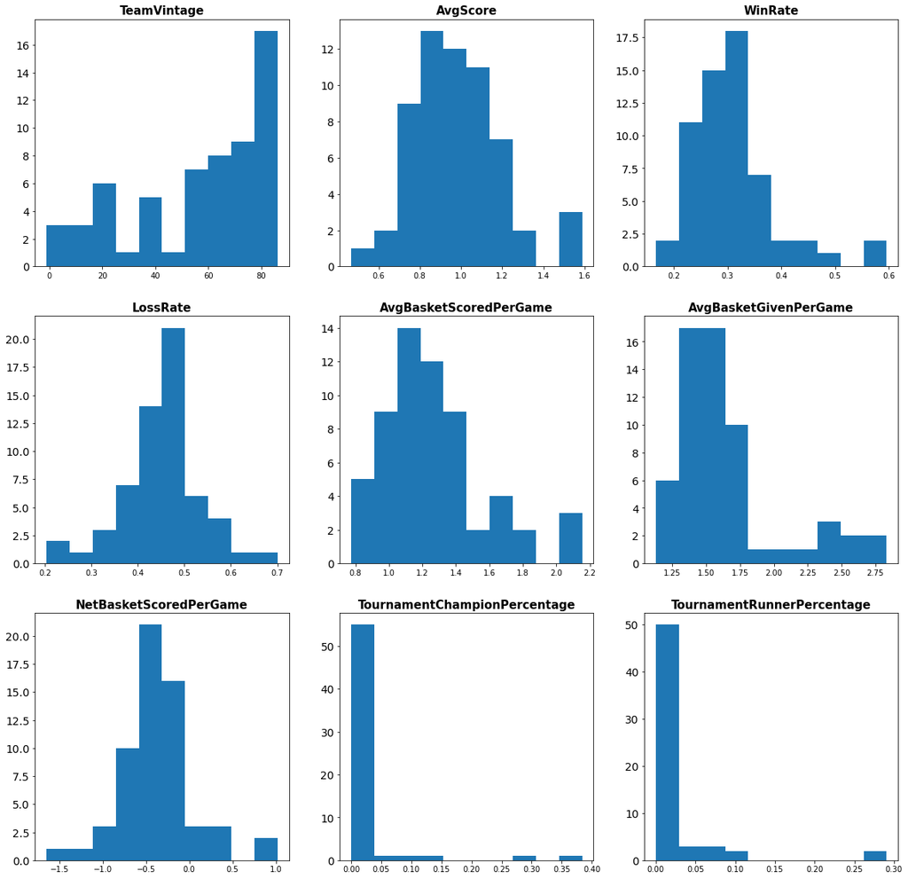

```python
#Plotting Histogram of all derived variables to understand frequency
fig, axs= plt.subplots(3,3,figsize=(20,20))

for i,ax in enumerate(axs.flat):
    ax.hist(df1[col[i]])
    ax.set_title(df1[col].columns[i],fontsize=15,fontweight='bold')
    ax.tick_params(axis='y',labelsize=14)

plt.show()
```

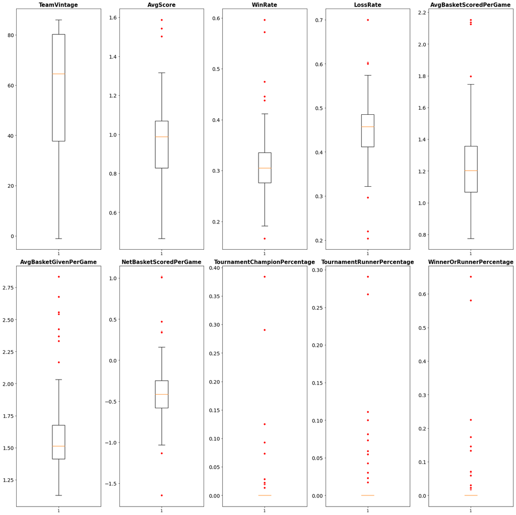

```python
#Plotting Boxplot of all derived variables to understand Outliers, Median values and different quartile range values

red_circle=dict(markerfacecolor='red',marker='o',markeredgecolor='white')

fig, axs= plt.subplots(2,5,figsize=(20,20))

for i,ax in enumerate(axs.flat):
    ax.boxplot(df1[col[i]],flierprops=red_circle)
    ax.set_title(df1[col].columns[i],fontsize=15,fontweight='bold')
    ax.tick_params(axis='y',labelsize=14)

plt.tight_layout()
```

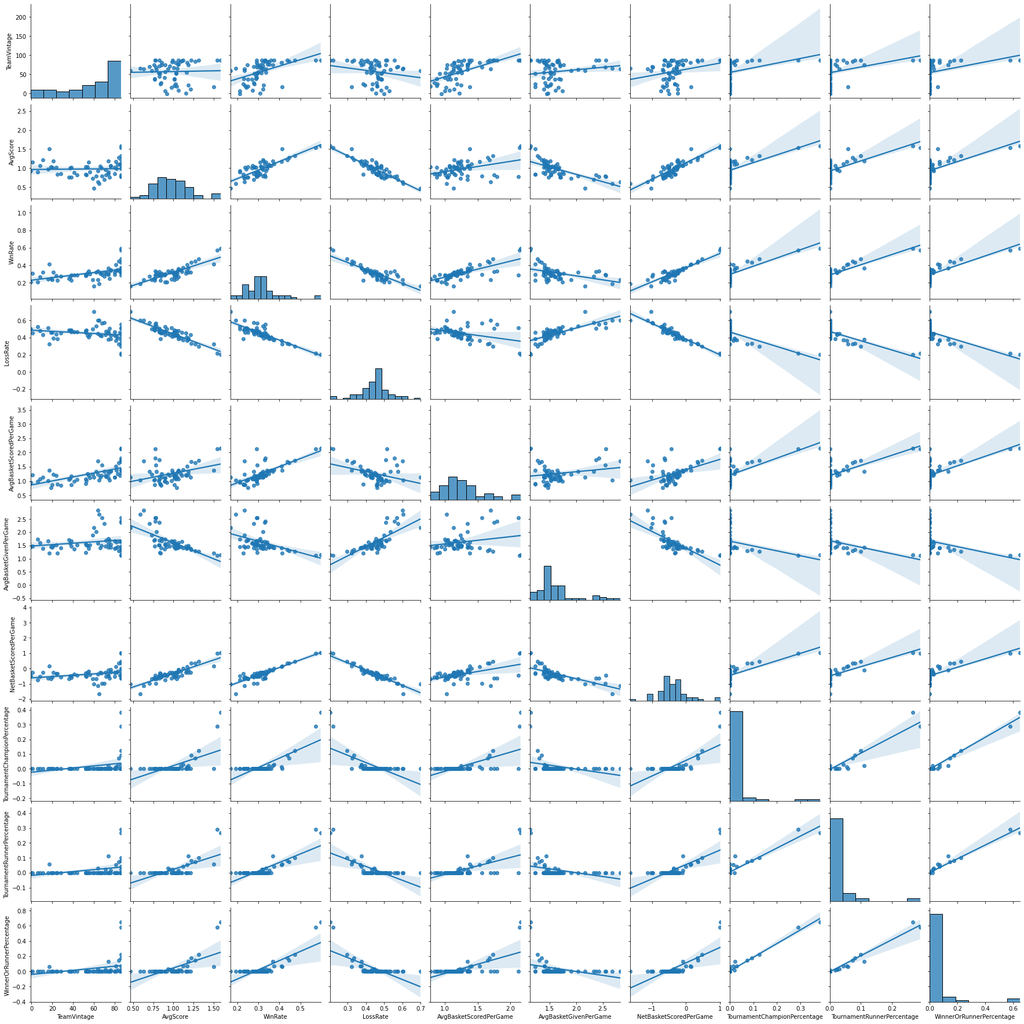

```python
#Plotting pairplot to understand correlation between variables
sns.pairplot(df1[col], kind="reg")  # plots scatter plots for every pair of attributes and histograms along the diagonal
plt.show()
```

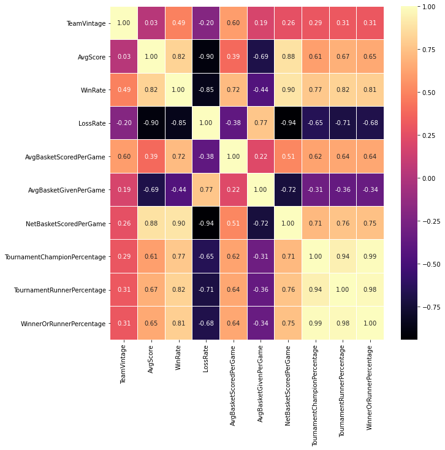

```python
#Plotting Heatmap to understand correlation between variables
fig,ax = plt.subplots(figsize=(10, 10))
sns.heatmap(df1[col].corr(), ax=ax, annot=True, linewidths=0.05, fmt= '.2f',cmap="magma") # the color intensity is based on
plt.show()
```

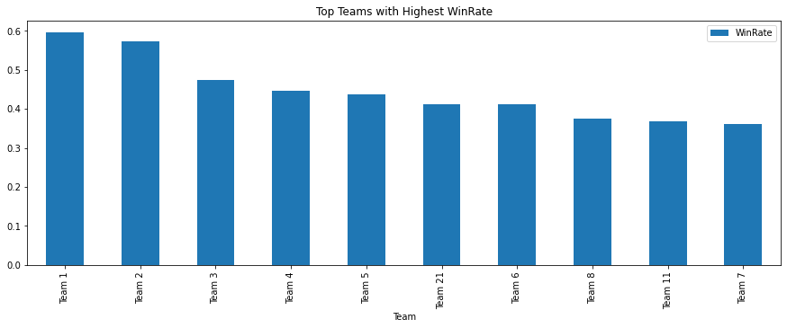

```python
df1[['Team','WinRate']].sort_values(['WinRate'],ascending=False).head(10).plot(x='Team',y='WinRate',kind='bar',
                                                                               figsize=(15,5))
plt.title('Top Teams with Highest WinRate')
plt.show()
```

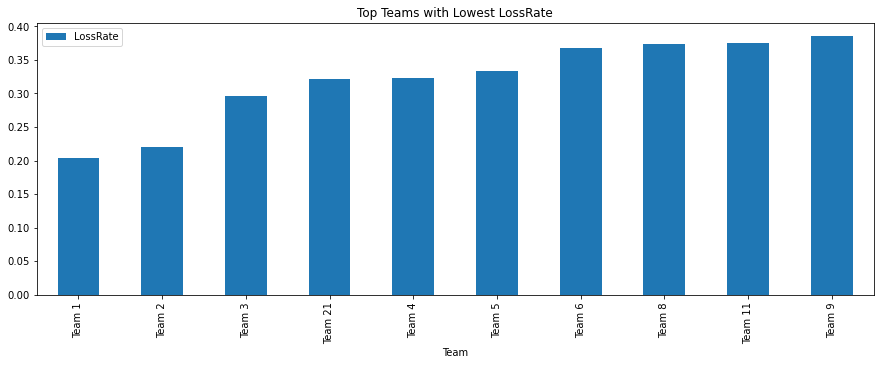

```python
df1[['Team','LossRate']].sort_values(['LossRate'],ascending=True).head(10).plot(x='Team',y='LossRate',kind='bar',
                                                                               figsize=(15,5))
plt.title('Top Teams with Lowest LossRate')
plt.show()
```

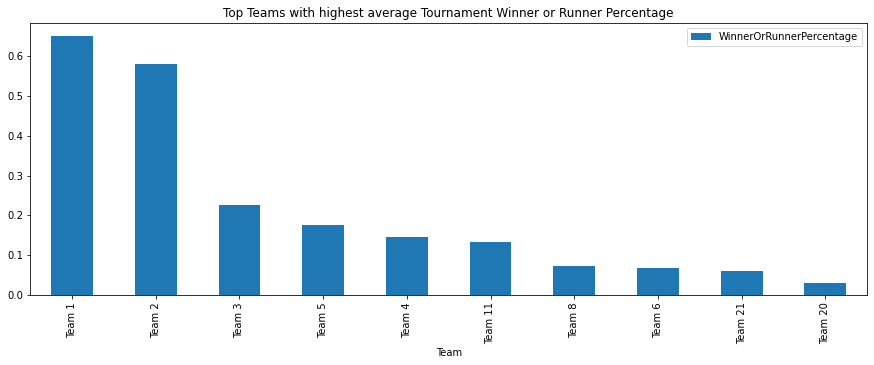

```python
df1[['Team','WinnerOrRunnerPercentage']].sort_values(['WinnerOrRunnerPercentage'],ascending=False).head(10).plot(x='Team',y='WinnerOrRunnerPercentage',kind='bar',
                                                                               figsize=(15,5))
plt.title('Top Teams with highest average Tournament Winner or Runner Percentage')
plt.show()
```

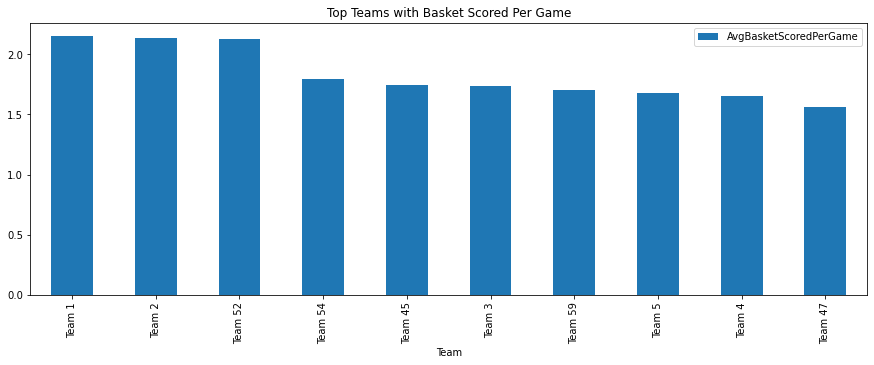

```python
df1[['Team','AvgBasketScoredPerGame']].sort_values(['AvgBasketScoredPerGame'],ascending=False).head(10).plot(x='Team',
                                                            y='AvgBasketScoredPerGame',kind='bar',figsize=(15,5))
plt.title('Top Teams with Basket Scored Per Game')
plt.show()
```

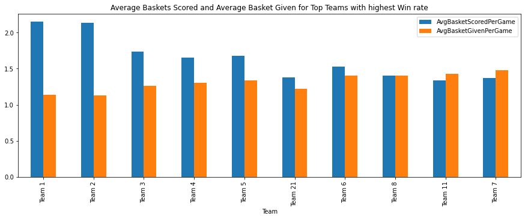

```python
df1.sort_values(['WinRate'],ascending=False).head(10).plot(x='Team',y=['AvgBasketScoredPerGame','AvgBasketGivenPerGame'],kind='bar',
                                                                               figsize=(15,5))
plt.title('Average Baskets Scored and Average Basket Given for Top Teams with highest Win rate')
plt.show()
```

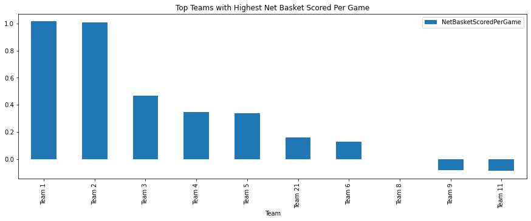

```python
df1[['Team','NetBasketScoredPerGame']].sort_values(['NetBasketScoredPerGame'],ascending=False).head(10).plot(x='Team',y='NetBasketScoredPerGame',kind='bar',
                                                                               figsize=(15,5))
plt.title('Top Teams with Highest Net Basket Scored Per Game')
plt.show()
```

```python
df1[['Team','WinRate','TeamVintage','AvgScore','LossRate','AvgBasketScoredPerGame','AvgBasketGivenPerGame',
     'NetBasketScoredPerGame','TournamentChampionPercentage','TournamentRunnerPercentage','WinnerOrRunnerPercentage']].sort_values('WinRate',ascending=False).head(10).style.format({
    'AvgScore': '{:,.2}'.format,
    'WinRate': '{:,.2%}'.format,
    'LossRate': '{:,.2%}'.format,
    'AvgBasketScoredPerGame': '{:,.2}'.format,
    'AvgBasketGivenPerGame': '{:,.2}'.format,
    'NetBasketScoredPerGame': '{:,.2}'.format,
    'TournamentChampionPercentage': '{:,.2%}'.format,
    'TournamentRunnerPercentage': '{:,.2%}'.format,
    'WinnerOrRunnerPercentage': '{:,.2%}'.format,
})
```

|  | Team | WinRate | TeamVintage | AvgScore | LossRate | AvgBasketScoredPerGame | AvgBasketGivenPerGame | NetBasketScoredPerGame | TournamentChampionPercentage | TournamentRunnerPercentage | WinnerOrRunnerPercentage |
| --- | --- | --- | --- | --- | --- | --- | --- | --- | --- | --- | --- |
| 0 | Team 1 | 59.63% | 86 | 1.6 | 20.38% | 2.2 | 1.1 | 1.0 | 38.37% | 26.74% | 65.12% |
| 1 | Team 2 | 57.24% | 86 | 1.5 | 22.01% | 2.1 | 1.1 | 1.0 | 29.07% | 29.07% | 58.14% |
| 2 | Team 3 | 47.48% | 86 | 1.3 | 29.65% | 1.7 | 1.3 | 0.47 | 12.50% | 10.00% | 22.50% |
| 3 | Team 4 | 44.56% | 84 | 1.3 | 32.32% | 1.7 | 1.3 | 0.35 | 7.32% | 7.32% | 14.63% |
| 4 | Team 5 | 43.77% | 86 | 1.2 | 33.31% | 1.7 | 1.3 | 0.34 | 9.30% | 8.14% | 17.44% |
| 20 | Team 21 | 41.18% | 17 | 1.5 | 32.20% | 1.4 | 1.2 | 0.16 | 0.00% | 5.88% | 5.88% |
| 5 | Team 6 | 41.11% | 81 | 1.2 | 36.84% | 1.5 | 1.4 | 0.13 | 1.37% | 5.48% | 6.85% |
| 7 | Team 8 | 37.53% | 86 | 1.1 | 37.40% | 1.4 | 1.4 | -0.00087 | 2.86% | 4.29% | 7.14% |
| 10 | Team 11 | 36.80% | 74 | 1.2 | 37.58% | 1.3 | 1.4 | -0.089 | 2.22% | 11.11% | 13.33% |
| 6 | Team 7 | 36.10% | 86 | 1.1 | 40.75% | 1.4 | 1.5 | -0.11 | 0.00% | 0.00% | 0.00% |

```python
df1[['Team','WinRate','TeamVintage','AvgScore','LossRate','AvgBasketScoredPerGame','AvgBasketGivenPerGame',
     'NetBasketScoredPerGame','TournamentChampionPercentage','TournamentRunnerPercentage','WinnerOrRunnerPercentage']][(df1.TeamVintage<=60)].sort_values('WinRate',ascending=False).head(10).style.format({
    'AvgScore': '{:,.2}'.format,
    'WinRate': '{:,.2%}'.format,
    'LossRate': '{:,.2%}'.format,
    'AvgBasketScoredPerGame': '{:,.2}'.format,
    'AvgBasketGivenPerGame': '{:,.2}'.format,
    'NetBasketScoredPerGame': '{:,.2}'.format,
    'TournamentChampionPercentage': '{:,.2%}'.format,
    'TournamentRunnerPercentage': '{:,.2%}'.format,
    'WinnerOrRunnerPercentage': '{:,.2%}'.format,
})
```

|  | Team | WinRate | TeamVintage | AvgScore | LossRate | AvgBasketScoredPerGame | AvgBasketGivenPerGame | NetBasketScoredPerGame | TournamentChampionPercentage | TournamentRunnerPercentage | WinnerOrRunnerPercentage |
| --- | --- | --- | --- | --- | --- | --- | --- | --- | --- | --- | --- |
| 20 | Team 21 | 41.18% | 17 | 1.5 | 32.20% | 1.4 | 1.2 | 0.16 | 0.00% | 5.88% | 5.88% |
| 18 | Team 19 | 33.70% | 55 | 1.2 | 40.38% | 1.2 | 1.4 | -0.19 | 0.00% | 0.00% | 0.00% |
| 38 | Team 39 | 32.50% | 21 | 1.2 | 39.38% | 1.2 | 1.5 | -0.26 | 0.00% | 0.00% | 0.00% |
| 24 | Team 25 | 32.24% | 11 | 1.2 | 43.20% | 1.1 | 1.4 | -0.25 | 0.00% | 0.00% | 0.00% |
| 26 | Team 27 | 31.38% | 54 | 1.0 | 42.71% | 1.3 | 1.5 | -0.25 | 0.00% | 0.00% | 0.00% |
| 43 | Team 44 | 30.70% | 1 | 1.2 | 45.61% | 1.2 | 1.5 | -0.25 | 0.00% | 0.00% | 0.00% |
| 23 | Team 24 | 29.94% | 56 | 0.89 | 43.51% | 1.1 | 1.5 | -0.4 | 0.00% | 0.00% | 0.00% |
| 41 | Team 42 | 29.44% | 52 | 0.83 | 46.11% | 0.92 | 1.2 | -0.31 | 0.00% | 0.00% | 0.00% |
| 37 | Team 38 | 29.08% | 53 | 0.82 | 48.58% | 1.0 | 1.5 | -0.51 | 0.00% | 0.00% | 0.00% |
| 30 | Team 31 | 29.08% | 41 | 0.89 | 46.81% | 1.0 | 1.4 | -0.38 | 0.00% | 0.00% | 0.00% |

```python
df1[['Team','WinRate','TeamVintage','AvgScore','LossRate','AvgBasketScoredPerGame','AvgBasketGivenPerGame',
     'NetBasketScoredPerGame','TournamentChampionPercentage','TournamentRunnerPercentage','WinnerOrRunnerPercentage']][(df1.TeamVintage<=60)].sort_values('LossRate',ascending=True).head(10).style.format({
    'AvgScore': '{:,.2}'.format,
    'WinRate': '{:,.2%}'.format,
    'LossRate': '{:,.2%}'.format,
    'AvgBasketScoredPerGame': '{:,.2}'.format,
    'AvgBasketGivenPerGame': '{:,.2}'.format,
    'NetBasketScoredPerGame': '{:,.2}'.format,
    'TournamentChampionPercentage': '{:,.2%}'.format,
    'TournamentRunnerPercentage': '{:,.2%}'.format,
    'WinnerOrRunnerPercentage': '{:,.2%}'.format,
})
```

|  | Team | WinRate | TeamVintage | AvgScore | LossRate | AvgBasketScoredPerGame | AvgBasketGivenPerGame | NetBasketScoredPerGame | TournamentChampionPercentage | TournamentRunnerPercentage | WinnerOrRunnerPercentage |
| --- | --- | --- | --- | --- | --- | --- | --- | --- | --- | --- | --- |
| 20 | Team 21 | 41.18% | 17 | 1.5 | 32.20% | 1.4 | 1.2 | 0.16 | 0.00% | 5.88% | 5.88% |
| 45 | Team 46 | 22.81% | 25 | 0.84 | 38.60% | 0.89 | 1.2 | -0.33 | 0.00% | 0.00% | 0.00% |
| 38 | Team 39 | 32.50% | 21 | 1.2 | 39.38% | 1.2 | 1.5 | -0.26 | 0.00% | 0.00% | 0.00% |
| 18 | Team 19 | 33.70% | 55 | 1.2 | 40.38% | 1.2 | 1.4 | -0.19 | 0.00% | 0.00% | 0.00% |
| 26 | Team 27 | 31.38% | 54 | 1.0 | 42.71% | 1.3 | 1.5 | -0.25 | 0.00% | 0.00% | 0.00% |
| 24 | Team 25 | 32.24% | 11 | 1.2 | 43.20% | 1.1 | 1.4 | -0.25 | 0.00% | 0.00% | 0.00% |
| 23 | Team 24 | 29.94% | 56 | 0.89 | 43.51% | 1.1 | 1.5 | -0.4 | 0.00% | 0.00% | 0.00% |
| 35 | Team 36 | 28.15% | 24 | 1.0 | 43.70% | 1.2 | 1.5 | -0.33 | 0.00% | 0.00% | 0.00% |
| 43 | Team 44 | 30.70% | 1 | 1.2 | 45.61% | 1.2 | 1.5 | -0.25 | 0.00% | 0.00% | 0.00% |
| 33 | Team 34 | 27.75% | 28 | 0.85 | 45.66% | 0.84 | 1.4 | -0.57 | 0.00% | 0.00% | 0.00% |

Conclusions:

Assumptions for making Recommendations: As details of which Team already in Contract with Competitors is not available, I am assuming all the teams with Team Launch Vintage of Greater than 60 Years are under contract.

Recommendations:

- 1st Choice - Team 21: Team 21 has highest win rate of 41% among teams with <=60 Years vintage. Also they have very low Loss rate of only 32% where as the average Loss Rate is 45%. They have also been Runner Up once. Average Basket Scored per game is 1.38 which is among top 25% teams. They also have third highest Average Score of 1.50 which is only below Team 1 and Team 2.
- 2nd Choice - Team 19: Team 19 has very good Win Rate of 34% and have drawn 26% of the games. Loss rate is below the median loss rate of 46%. They also have good defence with Average Basket Given of only 1.39 which is among 25% population. Also Average Score is 1.16 which is among top 25%. They have also been at Highest Position of 3.
1. Please include any improvements or suggestions to the association management on quality, quantity, variety, velocity, veracity etc. on the data points collected by the association to perform a better data analysis in future. At-least 1 suggestion for each point. [10 Marks]

Time Series Data: It would be great if we had a time series data available for the analysis. It would have helped to see if Team Performance has changed in recent years and we could have also considered the same for taking decision.

Quality: The shared data had special character '-'. In the current context I am assuming it is used for 0 values. However Team 61 has '-' for most of fields field even though they have participated in 1 tournament.

Quantity: We have summarized details for 61 teams in the shared dataset. However to derive any meaningful insigts by applying ML algoritams we will need more data points. It would have helped if had details of more teams if available. Also details of which Team are already under Contract with Competitors would have helped for final recommendations.

Variety: We were shared a csv file with summarized performance details for 61 teams. We could have also used data from other sources like Social Media to understand which teams are most popular .

Velocity: As per the data the olderst Team was launched in 1929 and has played maximum 86 Tournaments. So have assumed current Year as 1929+86=2015. Since we are in 2021 we are missing 6 Years of data.

Veracity: The average baskets scored per game is in range of 0.77 to 2.15 which is too low. Similarly Average Basket given per game is in range of 1.12 to 2.83 which again is too low.

# --------------------------------------------------- Part 3 -----------------------------------------15 Marks

Project Objective: Analyse the data of the various companies from the given dataset and perform the tasks that are specified in the below steps. Draw insights from the various attributes that are present in the dataset, plot distributions, state hypotheses and draw conclusions from the dataset.

● Steps and Tasks:

1. Read the CSV file.

```python
data=pd.read_csv('CompanyX_EU.csv')
df2=data
df2.head()
```

|  | Startup | Product | Funding | Event | Result | OperatingState |
| --- | --- | --- | --- | --- | --- | --- |
| 0 | 2600Hz | 2600hz.com | NaN | Disrupt SF 2013 | Contestant | Operating |
| 1 | 3DLT | 3dlt.com | $630K | Disrupt NYC 2013 | Contestant | Closed |
| 2 | 3DPrinterOS | 3dprinteros.com | NaN | Disrupt SF 2016 | Contestant | Operating |
| 3 | 3Dprintler | 3dprintler.com | $1M | Disrupt NY 2016 | Audience choice | Operating |
| 4 | 42 Technologies | 42technologies.com | NaN | Disrupt NYC 2013 | Contestant | Operating |

1. Data exploration: [1 Mark]

○ Check the datatypes of each attribute.

```python
df2.dtypes #Checking data type of each attribute
```

```
Startup           object
Product           object
Funding           object
Event             object
Result            object
OperatingState    object
dtype: object
```

○ Check for null values in the attributes.

```python
df2.info() #Checking null Values
```

```
<class 'pandas.core.frame.DataFrame'>
RangeIndex: 662 entries, 0 to 661
Data columns (total 6 columns):
 #   Column          Non-Null Count  Dtype
---  ------          --------------  -----
 0   Startup         662 non-null    object
 1   Product         656 non-null    object
 2   Funding         448 non-null    object
 3   Event           662 non-null    object
 4   Result          662 non-null    object
 5   OperatingState  662 non-null    object
dtypes: object(6)
memory usage: 31.2+ KB
```

```python
df2.isna().sum() #Checking null Values
```

```
Startup             0
Product             6
Funding           214
Event               0
Result              0
OperatingState      0
dtype: int64
```

1. Data preprocessing & visualisation:

○ Drop the null values. [1 Mark]

```python
df2.dropna(axis=0, how='any', inplace=True)
df2.info()
```

```
<class 'pandas.core.frame.DataFrame'>
Int64Index: 446 entries, 1 to 661
Data columns (total 6 columns):
 #   Column          Non-Null Count  Dtype
---  ------          --------------  -----
 0   Startup         446 non-null    object
 1   Product         446 non-null    object
 2   Funding         446 non-null    object
 3   Event           446 non-null    object
 4   Result          446 non-null    object
 5   OperatingState  446 non-null    object
dtypes: object(6)
memory usage: 24.4+ KB
```

Convert the ‘Funding’ features to a numerical value.

```python
df2.loc[:,'Funds_in_million'] = df2['Funding'].apply(lambda x: float(x[1:-1])/1000 if x[-1] == 'K' else (float(x[1:-1])*1000 if x[-1] == 'B' else float(x[1:-1])))

df2.head()
```

|  | Startup | Product | Funding | Event | Result | OperatingState | Funds_in_million |
| --- | --- | --- | --- | --- | --- | --- | --- |
| 1 | 3DLT | 3dlt.com | $630K | Disrupt NYC 2013 | Contestant | Closed | 0.63 |
| 3 | 3Dprintler | 3dprintler.com | $1M | Disrupt NY 2016 | Audience choice | Operating | 1.00 |
| 5 | 5to1 | 5to1.com | $19.3M | TC50 2009 | Contestant | Acquired | 19.30 |
| 6 | 8 Securities | 8securities.com | $29M | Disrupt Beijing 2011 | Finalist | Operating | 29.00 |
| 10 | AdhereTech | adheretech.com | $1.8M | Hardware Battlefield 2014 | Contestant | Operating | 1.80 |

Plot box plot for funds in million. [1 Mark]

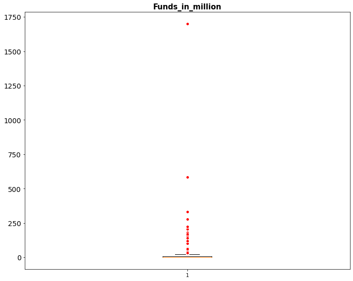

```python
#Plotting Boxplot

red_circle=dict(markerfacecolor='red',marker='o',markeredgecolor='white')

fig, axs= plt.subplots(1,1,figsize=(10,8))

axs.boxplot(df2['Funds_in_million'],flierprops=red_circle)
axs.set_title('Funds_in_million',fontsize=15,fontweight='bold')
axs.tick_params(axis='y',labelsize=14)

plt.tight_layout()
```

○ Check the number of outliers greater than the upper fence. [1 Mark]

```python
IQR=df2['Funds_in_million'].quantile(0.75)-df2['Funds_in_million'].quantile(0.25)
Max_Whisker=df2['Funds_in_million'].quantile(0.75)+(1.5*IQR)
```

[output not shown]

```python
details = df2.apply(lambda x : True
            if x['Funds_in_million'] > Max_Whisker else False, axis = 1)

num_rows = len(details[details == True].index)

print('Number of outliers greater than the upper fence: ',
      num_rows )
```

```
Number of outliers greater than the upper fence:  60
```

○ Check frequency of the OperatingState features classes. [1 Mark]

```python
df2.OperatingState.value_counts()
```

```
Operating    319
Acquired      66
Closed        57
Ipo            4
Name: OperatingState, dtype: int64
```

1. Statistical Analysis:

○ Is there any significant difference between Funds raised by companies that are still operating vs companies that closed down? [1 Mark]

```python
# Sum of funds
df2[(df2['OperatingState']=='Operating') | (df2['OperatingState']=='Closed')].groupby(by='OperatingState')['Funds_in_million'].sum()
```

```
OperatingState
Closed        185.7157
Operating    6080.8372
Name: Funds_in_million, dtype: float64
```

```python
#Mean of Funds
df2[(df2['OperatingState']=='Operating') | (df2['OperatingState']=='Closed')].groupby(by='OperatingState')['Funds_in_million'].mean()
```

```
OperatingState
Closed        3.258170
Operating    19.062186
Name: Funds_in_million, dtype: float64
```

```python
#Median of Funds
df2[(df2['OperatingState']=='Operating') | (df2['OperatingState']=='Closed')].groupby(by='OperatingState')['Funds_in_million'].median()
```

```
OperatingState
Closed       0.9292
Operating    2.2000
Name: Funds_in_million, dtype: float64
```

As seen in the box plot the outliers are skewing the Mean Fund values for Operating accounts. The mean value for Operating account is 19.06 where as median is only 2.2.

To answer the question I am removing the outliers first and then try to answer the question.

```python
df3=df2[((df2['OperatingState']=='Operating') | (df2['OperatingState']=='Closed')) & (df2['Funds_in_million']<=Max_Whisker)]
df3.head()
```

|  | Startup | Product | Funding | Event | Result | OperatingState | Funds_in_million |
| --- | --- | --- | --- | --- | --- | --- | --- |
| 1 | 3DLT | 3dlt.com | $630K | Disrupt NYC 2013 | Contestant | Closed | 0.63 |
| 3 | 3Dprintler | 3dprintler.com | $1M | Disrupt NY 2016 | Audience choice | Operating | 1.00 |
| 10 | AdhereTech | adheretech.com | $1.8M | Hardware Battlefield 2014 | Contestant | Operating | 1.80 |
| 11 | AdRocket | adrocket.com | $1M | TC50 2008 | Contestant | Closed | 1.00 |
| 13 | Agrilyst | agrilyst.com | $1M | Disrupt SF 2015 | Winner | Operating | 1.00 |

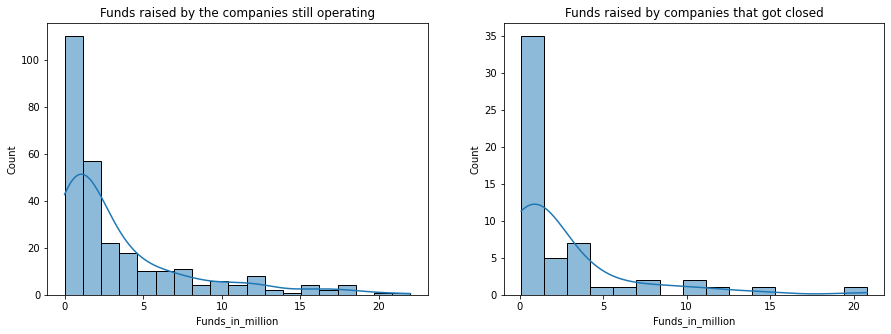

```python
fig, ax = plt.subplots(1, 2)

fig.set_figheight(5)
fig.set_figwidth(15)

sns.histplot(df3.loc[df3.OperatingState == 'Operating' , 'Funds_in_million'], ax = ax[0],kde=True)
sns.histplot(df3.loc[df3.OperatingState =='Closed', 'Funds_in_million'], ax = ax[1],kde=True)

ax[0].set_title('Funds raised by the companies still operating')
ax[1].set_title('Funds raised by companies that got closed')
plt.show()
```

Visibly the distribution of Funds looks similar for both Operating and Closed accounts. We can verify if there is a difference or not using Hypothesis Testing.

○ Write the null hypothesis and alternative hypothesis. [1 Mark]

Null Hypothesis Ho: There is no difference in Mean Fund Values for both companies that are still operating vs companies that closed down.

Alternate Hyporthesis Ha: Mean Fund value for Operating companies is not equal to Mean Fund value of closed companies.

○ Test for significance and conclusion [1 Mark]

```python
# For this testing we are keeping alpha=0.05 (95% Confidance)

alpha = 0.05
from statsmodels.stats.weightstats import ztest

sample1 = df3.loc[df3.OperatingState == 'Operating', 'Funds_in_million']
sample2 = df3.loc[df3.OperatingState =='Closed', 'Funds_in_million']



test_statistic, p_value = ztest(sample1, sample2)

if p_value <= alpha:
    print(f'Since the p-value, {round(p_value, 3)} < {alpha} (alpha) the difference is significant and we reject the Null hypothesis')
else:
    print(f'Since the p-value, {round(p_value,3)} > {alpha} (alpha) the difference is not significant and, we fail to reject the Null hypothesis''')
```

```
Since the p-value, 0.192 > 0.05 (alpha) the difference is not significant and, we fail to reject the Null hypothesis
```

Make a copy of the original data frame. [1 Mark]

```python
df4 = data.copy()
df4.head()
```

|  | Startup | Product | Funding | Event | Result | OperatingState |
| --- | --- | --- | --- | --- | --- | --- |
| 0 | 2600Hz | 2600hz.com | NaN | Disrupt SF 2013 | Contestant | Operating |
| 1 | 3DLT | 3dlt.com | $630K | Disrupt NYC 2013 | Contestant | Closed |
| 2 | 3DPrinterOS | 3dprinteros.com | NaN | Disrupt SF 2016 | Contestant | Operating |
| 3 | 3Dprintler | 3dprintler.com | $1M | Disrupt NY 2016 | Audience choice | Operating |
| 4 | 42 Technologies | 42technologies.com | NaN | Disrupt NYC 2013 | Contestant | Operating |

```python
df4.info()
```

```
<class 'pandas.core.frame.DataFrame'>
RangeIndex: 662 entries, 0 to 661
Data columns (total 6 columns):
 #   Column          Non-Null Count  Dtype
---  ------          --------------  -----
 0   Startup         662 non-null    object
 1   Product         656 non-null    object
 2   Funding         448 non-null    object
 3   Event           662 non-null    object
 4   Result          662 non-null    object
 5   OperatingState  662 non-null    object
dtypes: object(6)
memory usage: 31.2+ KB
```

○ Check frequency distribution of Result variables. [1 Mark]

```python
df4['Result'].value_counts()
```

```
Contestant         488
Finalist            84
Audience choice     41
Winner              26
Runner up           23
Name: Result, dtype: int64
```

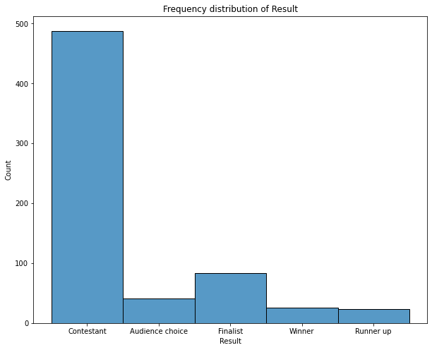

```python
fig, axs= plt.subplots(1,1,figsize=(10,8))

sns.histplot(df4['Result'])

plt.title('Frequency distribution of Result')
plt.show()
```

○ Calculate percentage of winners that are still operating and percentage of contestants that are still operating [1 Mark]

```python
Operating_Winners=df4['Result'][(df4.Result=='Winner') & (df4.OperatingState=='Operating')].value_counts().sum()
Winners=df4['Result'][(df4.Result=='Winner')].value_counts().sum()
Per_Win_Operating="{:.2%}".format(Operating_Winners/Winners)

Operating_contestant=df4['Result'][(df4.Result=='Contestant') & (df4.OperatingState=='Operating')].value_counts().sum()
Contestants=df4['Result'][(df4.Result=='Contestant')].value_counts().sum()
Per_con_Operating="{:.2%}".format(Operating_contestant/Contestants)

print("Percentage of winners that are still operating is:",Per_Win_Operating)
print("Percentage of contestants that are still operating is:",Per_con_Operating)
```

```
Percentage of winners that are still operating is: 73.08%
Percentage of contestants that are still operating is: 68.03%
```

Write your hypothesis comparing the proportion of companies that are operating between winners and contestants: [2 Mark]

Null Hypothesis Ho: Proportion of Companies that are operating is same between Winners and Contestants

Alternate Hypothesis Ha: Proportion of Companies that are operating is different between Winners and Contestants

○ Test for significance and conclusion [1 Mark]

```python
# For this testing we are keeping alpha=0.05 (95% Confidance)

alpha=0.05
from statsmodels.stats.proportion import proportions_ztest

z_statistic, p_value = proportions_ztest([Operating_contestant, Operating_Winners], [Contestants, Winners])

if p_value <= alpha:
    print(f'Since the p-value, {round(p_value, 3)} < {alpha} (alpha) the difference is significant and we reject the Null hypothesis')
else:
    print(f'Since the p-value, {round(p_value,3)} > {alpha} (alpha) the difference is not significant and we fail to reject the Null hypothesis''')
```

```
Since the p-value, 0.59 > 0.05 (alpha) the difference is not significant and we fail to reject the Null hypothesis
```

○ Select only the Event that has ‘disrupt’ keyword from 2013 onwards. [1 Mark]

```python
Disrupt=df4['Event'][(df4['Event'].str.lower().str.contains('disrupt'))]
Disrupt_2013_Onwards=Disrupt[pd.to_numeric(Disrupt.str[-4:])>=2013]
print(Disrupt_2013_Onwards)
```

```
0          Disrupt SF 2013
1         Disrupt NYC 2013
2          Disrupt SF 2016
3          Disrupt NY 2016
4         Disrupt NYC 2013
              ...
646    Disrupt London 2015
648    Disrupt London 2015
653        Disrupt EU 2014
656       Disrupt NYC 2013
660        Disrupt SF 2013
Name: Event, Length: 276, dtype: object
```